# Przestępczość w Chicago

Piotr Otręba

2025-05-03

## Część 1. Obróbka danych.

```r
library(tidyverse)
library(forecast)
library(tseries)
library(urca)
```

Analiza obejmie podzbiór danych dotyczących przestępczości w Chicago w latach 2016-2020.

```r
setwd("C:\\Users\\48799\\OneDrive - Akademia Górniczo-Hutnicza im. Stanisława Staszica w Krakowie\\4_semestr\\Ekonometria\\ćw_laboratoryjne")
data <- read.csv("2016-2020-chicago-crime.csv")
```

Usuwamy nieistotne z punktu widzenia analizy zmienne.

```r
data <- data %>% select( -c("X", "ID", "Case.Number", "Location", "Updated.On"))
data <- data %>% rename("Type" = "Primary.Type")
```

Wyświetlamy unikatowe kategorie przestępstw.

```r
unique(data$Type)
```

```
##  [1] "THEFT"                             "DECEPTIVE PRACTICE"
##  [3] "OTHER OFFENSE"                     "MOTOR VEHICLE THEFT"
##  [5] "CRIM SEXUAL ASSAULT"               "BURGLARY"
##  [7] "CRIMINAL DAMAGE"                   "ASSAULT"
##  [9] "OFFENSE INVOLVING CHILDREN"        "BATTERY"
## [11] "SEX OFFENSE"                       "CRIMINAL SEXUAL ASSAULT"
## [13] "NARCOTICS"                         "WEAPONS VIOLATION"
## [15] "ROBBERY"                           "CRIMINAL TRESPASS"
## [17] "LIQUOR LAW VIOLATION"              "INTERFERENCE WITH PUBLIC OFFICER"
## [19] "ARSON"                             "PROSTITUTION"
## [21] "PUBLIC PEACE VIOLATION"            "OBSCENITY"
## [23] "STALKING"                          "KIDNAPPING"
## [25] "NON-CRIMINAL"                      "INTIMIDATION"
## [27] "CONCEALED CARRY LICENSE VIOLATION" "GAMBLING"
## [29] "NON-CRIMINAL (SUBJECT SPECIFIED)"  "NON - CRIMINAL"
## [31] "OTHER NARCOTIC VIOLATION"          "PUBLIC INDECENCY"
## [33] "HUMAN TRAFFICKING"                 "HOMICIDE"
## [35] "RITUALISM"
```

Grupujemy przestępstwa w większe kategorie.

```r
data <- data %>%
  mutate(Type = case_when(
    grepl("NON\\s?-\\s?CRIMINAL", Type) ~ "NON-CRIMINAL",
    grepl("NARCOTIC", Type) ~ "NARCOTICS",
    .default = Type
  ))
```

Podobnie, grupujemy opis lokalizacji, gdzie doszło do przestępstwa.Nazw lokalizacji jest na tyle dużo, że nie będziemy ich wyświetlać w sprawozdaniu.

```r
data <- data %>%
  mutate(Location_Category = case_when(
    # Lokalizacje mieszkalne
    grepl("RESIDENCE|APARTMENT|CHA APARTMENT|HOUSE|NURSING HOME|RETIREMENT HOME|ROOMING HOUSE|DRIVEWAY - RESIDENTIAL|RESIDENCE-GARAGE|RESIDENCE - GARAGE|RESIDENCE PORCH|RESIDENCE - PORCH|RESIDENTIAL YARD|RESIDENCE - YARD", Location.Description, ignore.case = TRUE) ~ "Residential",

    # Sklepy, biura, komercja
    grepl("COMMERCIAL|BUSINESS OFFICE|RETAIL|STORE|DEPARTMENT STORE|SMALL RETAIL|GROCERY|CONVENIENCE STORE|DRUG STORE|PAWN SHOP|TAVERN/LIQUOR|LIQUOR STORE|NEWSSTAND|APPLIANCE STORE|CLEANING STORE|AUTO / BOAT / RV DEALERSHIP", Location.Description, ignore.case = TRUE) ~ "Commercial",

    # Instytucje finansowe
    grepl("BANK|CURRENCY EXCHANGE|ATM|SAVINGS AND LOAN|CREDIT UNION", Location.Description, ignore.case = TRUE) ~ "Financial",

    # Usługi
    grepl("OFFICE|MEDICAL/DENTAL|MEDICAL / DENTAL|ANIMAL HOSPITAL|BARBERSHOP|BARBER SHOP/BEAUTY SALON", Location.Description, ignore.case = TRUE) ~ "Office/Service",

    # Związane z taksówkami, samochodami
    grepl("VEHICLE|CAR WASH|AUTO|TAXICAB|RIDE SHARE|UBER|LYFT|DELIVERY TRUCK|GARAGE/AUTO REPAIR", Location.Description, ignore.case = TRUE) ~ "Vehicle",

    # Parkingi
    grepl("PARKING LOT|GARAGE \\(NON|DRIVEWAY", Location.Description, ignore.case = TRUE) ~ "Parking",

    # Drogi i chodniki publiczne
    grepl("STREET|HIGHWAY|EXPRESSWAY|SIDEWALK|ALLEY|BRIDGE", Location.Description, ignore.case = TRUE) ~ "Public Roads",

    # Stacja benzynowa
    grepl("GAS STATION", Location.Description, ignore.case = TRUE) ~ "Gas Station",

    # Parki i tereny zielone
    grepl("PARK PROPERTY|FOREST PRESERVE|WOODED AREA|LAKEFRONT|WATERFRONT|RIVERBANK|RIVER BANK|LAKE|LAGOON", Location.Description, ignore.case = TRUE) ~ "Outdoor Green Areas",

    # Komunikacja miejska
    grepl("CTA|TRAIN|BUS|SUBWAY|PLATFORM|OTHER RAILROAD", Location.Description, ignore.case = TRUE) ~ "Public Transit",

    # Lotnisko
    grepl("AIRPORT|AIRCRAFT", Location.Description, ignore.case = TRUE) ~ "Airport",

    # Statki
    grepl("BOAT|WATERCRAFT", Location.Description, ignore.case = TRUE) ~ "Water/Maritime",

    # Placówki oświatowe
    grepl("SCHOOL|COLLEGE|UNIVERSITY", Location.Description, ignore.case = TRUE) ~ "Educational Institutions",

    # Instytucje federalne
    grepl("GOVERNMENT|FEDERAL|POLICE|JAIL|LOCK-UP|FIRE STATION", Location.Description, ignore.case = TRUE) ~ "Government/Security",

    # Służba zdrowia
    grepl("HOSPITAL|NURSING|RETIREMENT HOME", Location.Description, ignore.case = TRUE) ~ "Healthcare",

    # Miejsca kultu
    grepl("CHURCH|SYNAGOGUE|PLACE OF WORSHIP|CEMETARY", Location.Description, ignore.case = TRUE) ~ "Religious",

    # Rozrywka i rekreacja
    grepl("RESTAURANT|BAR|TAVERN|CLUB|POOL ROOM|ATHLETIC|SPORTS|STADIUM|MOVIE|THEATER|BOWLING", Location.Description, ignore.case = TRUE) ~ "Indoor Entertainment/Sports",

    # Hotele
    grepl("HOTEL|MOTEL", Location.Description, ignore.case = TRUE) ~ "Accommodation",

    # Tereny przemysłowe / plac budowy
    grepl("WAREHOUSE|FACTORY|MANUFACTURING|CONSTRUCTION", Location.Description, ignore.case = TRUE) ~ "Industrial",

    # Wnętrza budynków
    grepl("HALLWAY|STAIRWELL|VESTIBULE|ELEVATOR|PORCH|BASEMENT|YARD", Location.Description, ignore.case = TRUE) ~ "Building Areas",

    # Inne
    grepl("OTHER|SPECIFY", Location.Description, ignore.case = TRUE) ~ "Other",

    # Nieznane
    Location.Description == "" ~ "Unknown",

    # Wszystko inne
    TRUE ~ "Miscellaneous"
  ))
```

## Część 2. Analiza danych.

Sprawdźmy, gdzie doszło do największej liczby przestępstw.

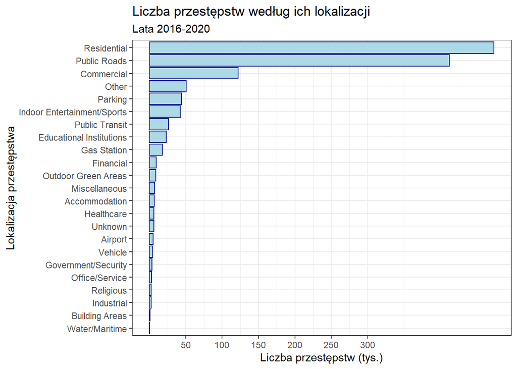

```r
data %>%
  group_by(Location_Category) %>%
  count() %>%
  ggplot(aes(y=reorder(Location_Category, n), x=n)) +
  geom_col(fill="lightblue", color="darkblue") +
  theme_bw() +
  scale_x_continuous(breaks= seq(5e4, 3e5, 5e4), labels = function(x) {x/1000}) +
  labs(title="Liczba przestępstw według ich lokalizacji",
       subtitle="Lata 2016-2020",
       y = "Lokalizacja przestępstwa",
       x = "Liczba przestępstw (tys.)")
```

Dla każdej lokalizacji wyświetlamy 3 najczęściej popełniane tam typy przzestępstw.

```r
data %>%
  group_by(Location_Category, Type) %>%
  summarize(count = n(), .groups = "drop") %>%
  group_by(Location_Category) %>%
  slice_max(order_by = count, n = 3)
```

```
## # A tibble: 69 × 3
## # Groups:   Location_Category [23]
##    Location_Category Type               count
##    <chr>             <chr>              <int>
##  1 Accommodation     THEFT               2422
##  2 Accommodation     BATTERY             1318
##  3 Accommodation     DECEPTIVE PRACTICE   663
##  4 Airport           THEFT               2018
##  5 Airport           DECEPTIVE PRACTICE   731
##  6 Airport           BATTERY              535
##  7 Building Areas    BATTERY              227
##  8 Building Areas    ASSAULT              225
##  9 Building Areas    HOMICIDE             221
## 10 Commercial        THEFT              65014
## # ℹ 59 more rows
```

Wyświetlamy 10 ogółem najczęściej popełnianych przestępstw.

```r
num_crimes <- data %>% group_by(Type) %>% count() %>% arrange(desc(n))
num_crimes
```

```
## # A tibble: 32 × 2
## # Groups:   Type [32]
##    Type                     n
##    <chr>                <int>
##  1 THEFT               294948
##  2 BATTERY             240349
##  3 CRIMINAL DAMAGE     139430
##  4 ASSAULT              97318
##  5 DECEPTIVE PRACTICE   95062
##  6 OTHER OFFENSE        81146
##  7 NARCOTICS            61158
##  8 BURGLARY             57419
##  9 MOTOR VEHICLE THEFT  51572
## 10 ROBBERY              49367
## # ℹ 22 more rows
```

Najczęściej dokonywanym typem przestępstwa była kradzież, na drugim miejscu pobicie, a na trzecim uszkodzenie mienia. Przedstawmy to na wykresie.

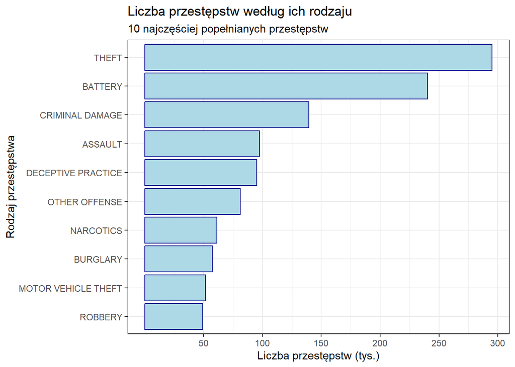

```r
num_crimes %>%
  head(10) %>%
  ggplot(aes(y=reorder(Type, n), x=n)) +
  geom_col(fill="lightblue", color="darkblue") +
  theme_bw() +
  scale_x_continuous(breaks= seq(5e4, 3e5, 5e4), labels = function(x) {x/1000}) +
  labs(title="Liczba przestępstw według ich rodzaju",
       subtitle="10 najczęściej popełnianych przestępstw",
       y = "Rodzaj przestępstwa",
       x = "Liczba przestępstw (tys.)")
```

Sprawdźmy też najrzadziej popełniane przestępstwa.

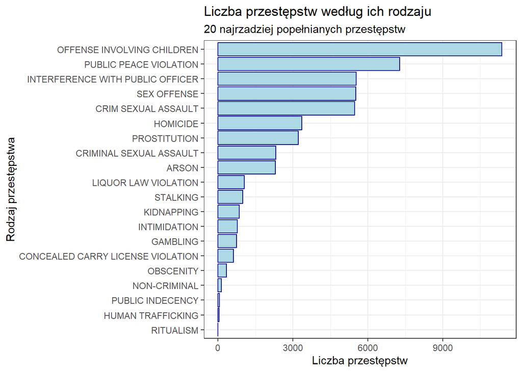

```r
num_crimes %>%
  tail(20) %>%
  ggplot(aes(y=reorder(Type, n), x=n)) +
  geom_col(fill="lightblue", color="darkblue") +
  theme_bw() +
  scale_x_continuous(breaks = seq(0, 12000, 3000)) +
  labs(title="Liczba przestępstw według ich rodzaju",
       subtitle="20 najrzadziej popełnianych przestępstw",
       y = "Rodzaj przestępstwa",
       x = "Liczba przestępstw")
```

Zobaczmy bardziej szczegółowo, jakie kradzieże były dokonywane.

```r
theft_types <- data %>%
  filter(Type == "THEFT") %>%
  group_by(Description) %>%
  count() %>%
  arrange(desc(n))
theft_types
```

```
## # A tibble: 11 × 2
## # Groups:   Description [11]
##    Description                               n
##    <chr>                                 <int>
##  1 $500 AND UNDER                       114493
##  2 OVER $500                             71254
##  3 RETAIL THEFT                          47305
##  4 FROM BUILDING                         47194
##  5 POCKET-PICKING                         9789
##  6 PURSE-SNATCHING                        2682
##  7 ATTEMPT THEFT                          1954
##  8 DELIVERY CONTAINER THEFT                172
##  9 FROM COIN-OP MACHINE/DEVICE              90
## 10 FROM COIN-OPERATED MACHINE OR DEVICE     14
## 11 THEFT RETAIL                              1
```

Najwięcej było kradzieży zaklasyfikowanych jako kradzież mienia o wartości nieprzekraczającej 500$. Sprawdzamy, czy występują wartości brakujące.

```r
sapply(names(data), function(col) {sum(is.na(data$col))})
```

```
##                 Date                Block                 IUCR
##                    0                    0                    0
##                 Type          Description Location.Description
##                    0                    0                    0
##               Arrest             Domestic                 Beat
##                    0                    0                    0
##             District                 Ward       Community.Area
##                    0                    0                    0
##             FBI.Code         X.Coordinate         Y.Coordinate
##                    0                    0                    0
##                 Year             Latitude            Longitude
##                    0                    0                    0
##    Location_Category
##                    0
```

Wartości brakujące nie występują.

Przekształcamy kolumnę z datą i godziną popełnienia przestępstwa.

```r
data <- data %>% mutate(Date = as_datetime(Date, format = "%m/%d/%Y %I:%M:%S %p"))
```

### Liczba przestępstw w zależności od pory dnia.

Tworzymy ramkę danych zawierającą liczbę przestępstw danego typu pogrupowanych wg godziny.

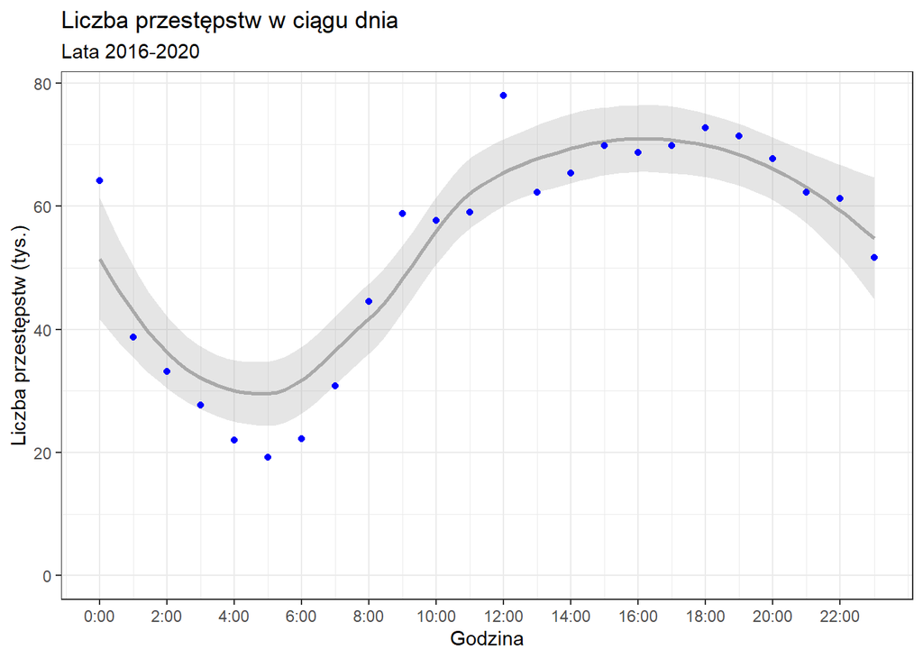

```r
crimes_by_hour <- data %>%
  mutate(hour = hour(Date)) %>%
  group_by(hour) %>%
  summarize(num_crimes = n())



ggplot(crimes_by_hour, aes(x=hour, y=num_crimes)) +
  geom_smooth(method="loess", formula= y~x, alpha=0.25, color="darkgray") +
  geom_point(color = "blue") +
  scale_y_continuous(breaks = seq(0, 8e4, 2e4), labels = function(x) x/1000) +
  expand_limits(y=0) +
  scale_x_continuous(breaks = seq(0, 23, 2), labels = function(x) paste(x, "00", sep=":")) +
  labs(title = "Liczba przestępstw w ciągu dnia",
       subtitle = "Lata 2016-2020",
       x = "Godzina",
       y = "Liczba przestępstw (tys.)") +
  theme_bw()
```

Najwięcej przestępstw (prawie 80 tys.) ma miejsce w godzinach południowych. Wiele przestępstw, bo około 70 tys., jest także popełnianych w godzinach popołudniowych i wczesnym wieczorem (15:00-19:00).

Sprawdźmy, czy różne przestępstwa są popełniane częściej o określonych porach dnia.

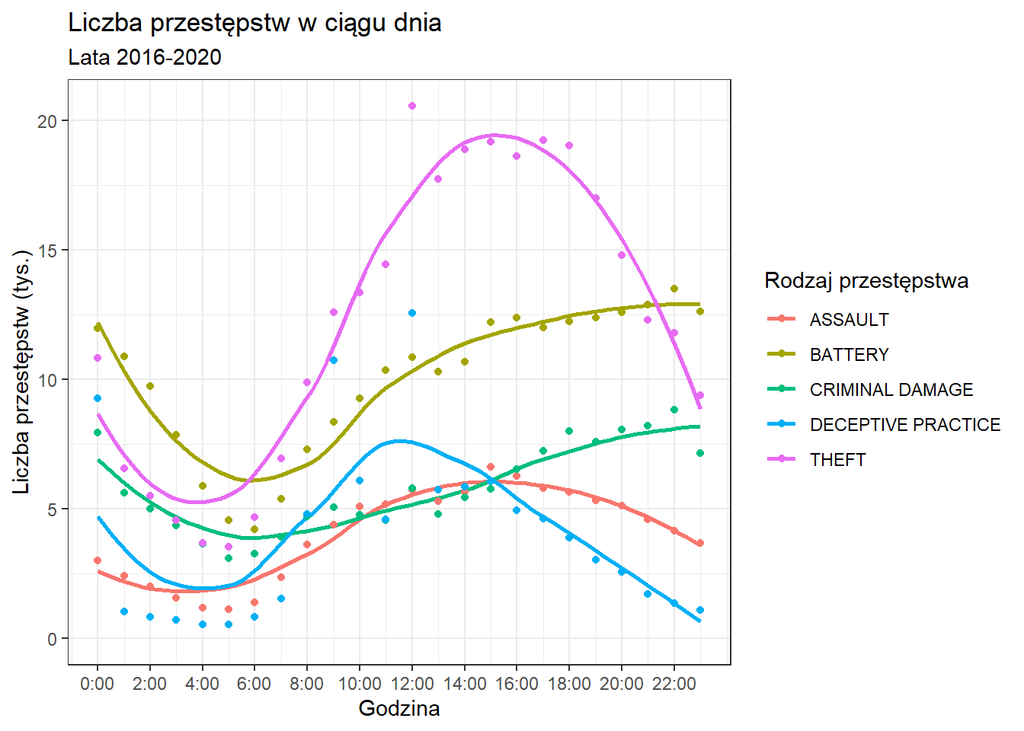

```r
crime_types_by_hour <- data %>%
  mutate(hour = hour(Date)) %>%
  group_by(hour, Type) %>%
  count()

crime_types_by_hour %>%
filter(Type %in% c("THEFT", "BATTERY", "ASSAULT", "CRIMINAL DAMAGE", "DECEPTIVE PRACTICE")) %>%
ggplot(aes(x=hour, y=n, color= Type)) +
  geom_smooth(method="loess", formula= y~x, alpha=0.25, se=F) +
  geom_point() +
  scale_y_continuous(breaks = seq(0, 2e4, 5e3), labels = function(x) x/1000) +
  expand_limits(y=0) +
  scale_x_continuous(breaks = seq(0, 23, 2), labels = function(x) paste(x, "00", sep=":")) +
  labs(title = "Liczba przestępstw w ciągu dnia",
       subtitle = "Lata 2016-2020",
       x = "Godzina",
       y = "Liczba przestępstw (tys.)",
       color = "Rodzaj przestępstwa") +
  theme_bw()
```

Najwięcej kradzieży ma miejsce w godz. 14:00-18:00. W przypadku pobicia i uszkodzenia mienia od godzin porannych następuje stopniowy wrost liczby tych przestępstw. W przypadku nieuczciwych praktyk najwięcej zdarzeń występuje w godz. 11:00-13:00. W godzinach wczesnoporannych i późnym wieczorem przestępstw tego typu jest znacznie mniej. Zapewne wynika to z faktu, że wiążą się one z handlem, a sklepy w tych godzinach są zamknięte.

Podobnie zwizualizujemy jeszcze inne przestępstwa, do których dochodziło rzadziej.

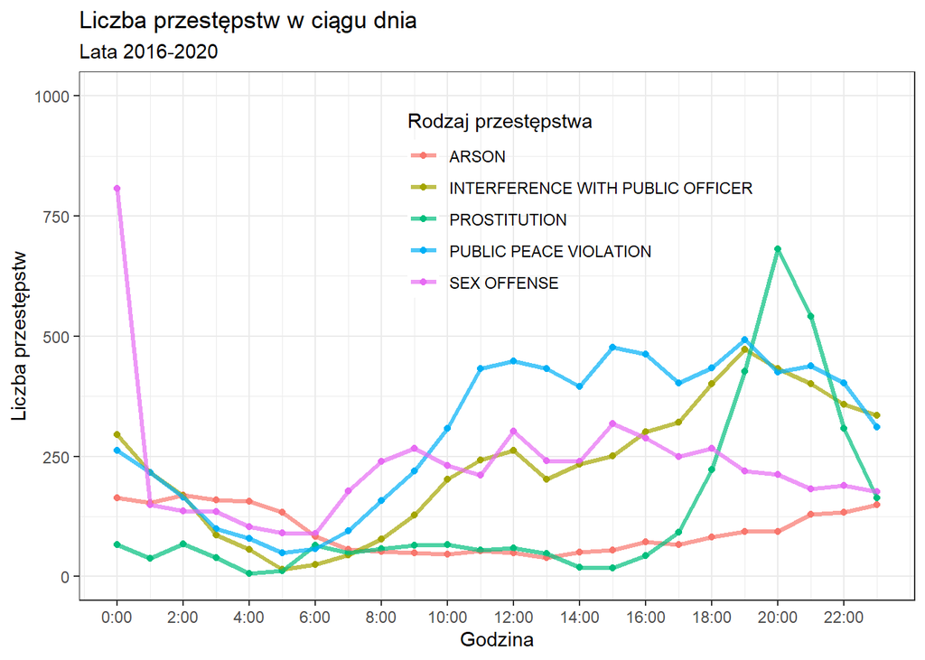

```r
crime_types_by_hour %>%
  filter(Type %in% c("PROSTITUTION",
                     "ARSON", "PUBLIC PEACE VIOLATION", "INTERFERENCE WITH PUBLIC OFFICER", "SEX OFFENSE")) %>%
  ggplot(aes(x=hour, y=n, color= Type)) +
  geom_point() +
  geom_line(linewidth=1.1, alpha=0.7) +
  scale_y_continuous(limits = c(0,1000)) +
  expand_limits(y=0) +
  scale_x_continuous(breaks = seq(0, 23, 2), labels = function(x) paste(x, "00", sep=":")) +
  labs(title = "Liczba przestępstw w ciągu dnia",
       subtitle = "Lata 2016-2020",
       x = "Godzina",
       y = "Liczba przestępstw",
       color = "Rodzaj przestępstwa") +
  theme_bw() +
  theme(legend.position = c(0.6, 0.75),
        legend.background = element_rect(fill = "transparent", color = NA),
        legend.box.background = element_rect(fill = "transparent", color = NA))
```

Przestępstwa na tle seksualnym mają miejsce najczęściej w okolicach północy. Liczba przestępstw polegających na zakłócaniu pracy funkcjonariusza publicznego stopniowo wzrasta od godzin porannych, osiągając maksimum w godzinach wieczornych. Najwięcej przypadków prostytucji odnotowano w godzinach 20:00-21:00. Podpaleń było niewiele, ale widzimy wzrost liczby tych przestępstw w godzinach nocnych.

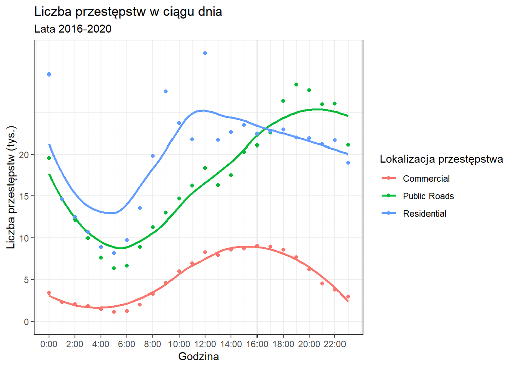

```r
crime_locations_by_hour <- data %>%
  mutate(hour = hour(Date)) %>%
  group_by(hour, Location_Category) %>%
  count()

crime_locations_by_hour %>%
filter(Location_Category%in% c("Residential", "Commercial", "Public Roads")) %>%
ggplot(aes(x=hour, y=n, color= Location_Category)) +
  geom_smooth(method="loess", formula= y~x, alpha=0.25, se=F) +
  geom_point() +
  scale_y_continuous(breaks = seq(0, 2e4, 5e3), labels = function(x) x/1000) +
  expand_limits(y=0) +
  scale_x_continuous(breaks = seq(0, 23, 2), labels = function(x) paste(x, "00", sep=":")) +
  labs(title = "Liczba przestępstw w ciągu dnia",
       subtitle = "Lata 2016-2020",
       x = "Godzina",
       y = "Liczba przestępstw (tys.)",
       color = "Lokalizacja przestępstwa") +
  theme_bw()
```

Liczba przestępstw / wykroczeń dokonywanych w rejonach mieszkalnych i na publicznych ulicach / chodnikach była wyraźnie najniższa wczesnym rankiem. Najwięcej przestępstw w rejonach mieszkalnych dokonywano między północą a 1 w nocy oraz w południe - wtedy mieszkańców prawdopodobnie nie ma w domu. Przestępstw na ulicach najwuęcej było między 19:00 a 20:00.

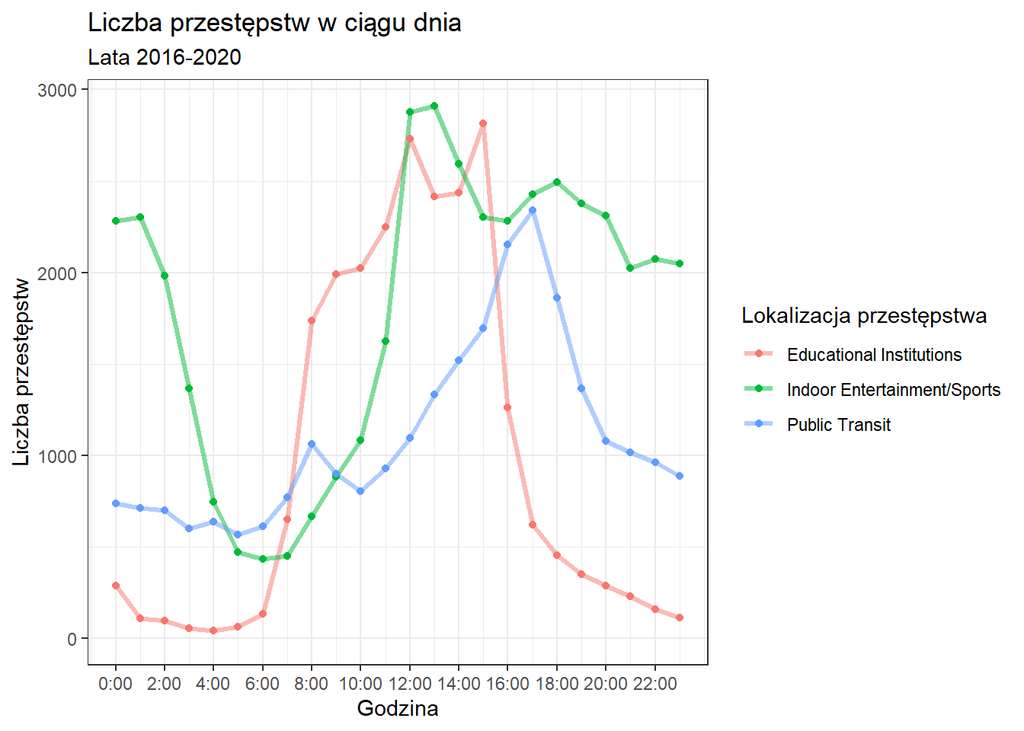

```r
crime_locations_by_hour %>%
filter(Location_Category%in% c("Educational Institutions", "Public Transit", "Indoor Entertainment/Sports")) %>%
ggplot(aes(x=hour, y=n, color= Location_Category)) +
  geom_line(linewidth=1.1, alpha=0.5) +
  geom_point() +
  expand_limits(y=0) +
  scale_x_continuous(breaks = seq(0, 23, 2), labels = function(x) paste(x, "00", sep=":")) +
  labs(title = "Liczba przestępstw w ciągu dnia",
       subtitle = "Lata 2016-2020",
       x = "Godzina",
       y = "Liczba przestępstw",
       color = "Lokalizacja przestępstwa") +
  theme_bw()
```

Przestępstwa w miejscach służących rekreacji i rozrywce mają miejsce najczęściej w godzinach 12:00-14:00, choć wieczorem wciąż utrzymują się na relatywnie wysokim poziomie. Najwięcej przestępstw w transporcie publicznym jest popełnianych między 17 a 18:00, kiedy ludzie wracają z pracy. Liczba przestępstw w placówkach edukacyjnych jest największa w godzinach, gdy zazwyczaj odbywają się lekcje / wykłady, czyli między 11:00 a 16:00.

### Liczba przestępstw w zależności od dnia tygodnia.

Na podstawie daty wyznaczamy dni tygodnia.

```r
data$Weekday <- factor(weekdays(data$Date),
                        levels= c("poniedziałek", "wtorek", "środa", "czwartek", "piątek", "sobota", "niedziela"))
```

Wyznaczamy liczby przestępstw danego rodzaju w zależności od dni tygodnia.

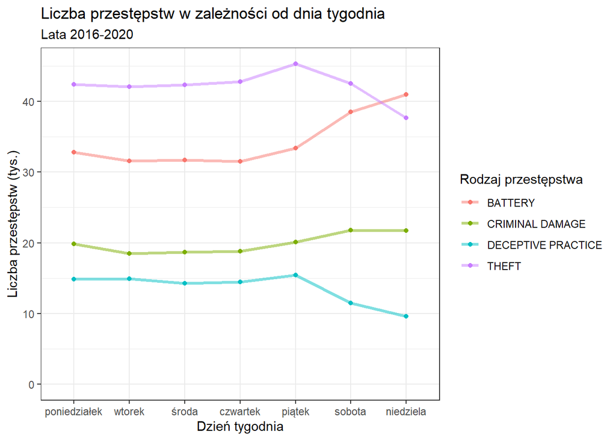

```r
crimes_by_weekday <- data %>%
  group_by(Weekday, Type) %>%
  summarize(num_crimes = n(), .groups="drop")

crimes_by_weekday %>%
  filter(Type %in% c("THEFT", "BATTERY", "CRIMINAL DAMAGE", "DECEPTIVE PRACTICE")) %>%
ggplot(aes(x=Weekday, y=num_crimes, color=Type, group=Type)) +
  geom_point() +
  geom_line(size=1.1, alpha=0.5) +
  scale_y_continuous(breaks = seq(0, 4e4, 1e4), labels = function(x) x/1000) +
  expand_limits(y=0) +
  labs(title = "Liczba przestępstw w zależności od dnia tygodnia",
       subtitle = "Lata 2016-2020",
       x = "Dzień tygodnia",
       y = "Liczba przestępstw (tys.)",
       color = "Rodzaj przestępstwa") +
  theme_bw()
```

Liczba kradzieży oraz nieuczciwych praktyk spada w weekendy. Wzrastają natomiast liczby pobić i nieznacznie wzrasta liczba zgłoszeń uszkodzeń mienia.

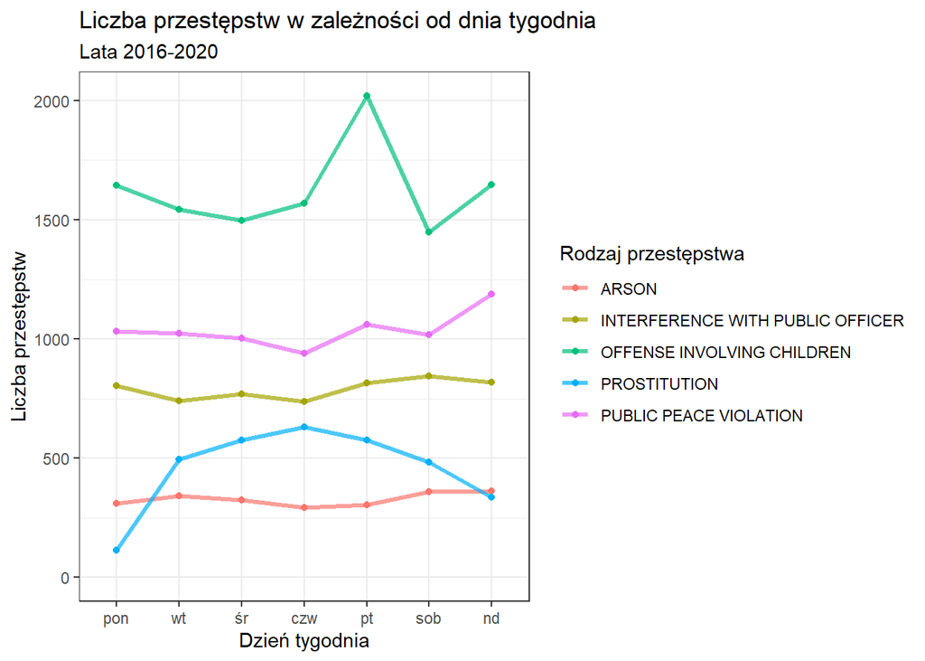

```r
crimes_by_weekday %>%
  filter(Type %in% c("PROSTITUTION",
                     "ARSON", "PUBLIC PEACE VIOLATION",
                     "INTERFERENCE WITH PUBLIC OFFICER",
                      "OFFENSE INVOLVING CHILDREN")) %>%
  ggplot(aes(x=Weekday, y=num_crimes, color= Type, group=Type)) +
  scale_x_discrete(labels = c("pon", "wt", "śr", "czw", "pt", "sob", "nd")) +
  geom_point() +
  geom_line(size=1.1, alpha=0.7) +
  expand_limits(y=0) +
  labs(title = "Liczba przestępstw w zależności od dnia tygodnia",
       subtitle = "Lata 2016-2020",
       x = "Dzień tygodnia",
       y = "Liczba przestępstw",
       color = "Rodzaj przestępstwa") +
  theme_bw()
```

W piątki zwyżkuje liczba przestępstw z udziałem nieletnich. W niedziele odnotowano więcej przypadków zakłóceń porządku publicznego. Najwięcej zgłoszonych przypadków prostytucji było w tygodniu, a w weekendy ta liczba malała.

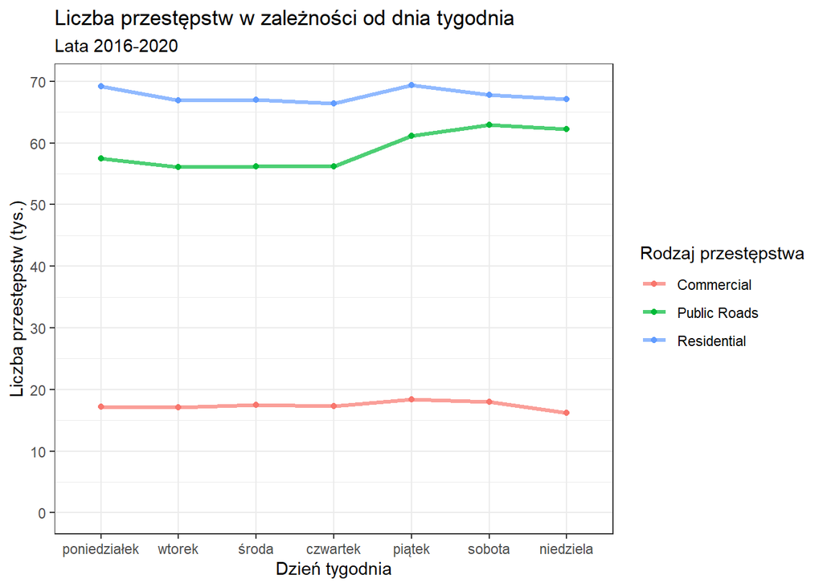

```r
crime_locations_by_weekday <- data %>%
  group_by(Weekday, Location_Category) %>%
  summarize(num_crimes = n(), .groups= "drop")

crime_locations_by_weekday %>%
  filter(Location_Category %in% c("Residential", "Commercial", "Public Roads")) %>%
  ggplot(aes(x=Weekday, y=num_crimes, color= Location_Category, group=Location_Category)) +
  geom_point() +
  scale_y_continuous(breaks = seq(0, 7e4, 1e4), labels = function(x) x/1000)+
  geom_line(size=1.1, alpha=0.7) +
  expand_limits(y=0) +
  labs(title = "Liczba przestępstw w zależności od dnia tygodnia",
       subtitle = "Lata 2016-2020",
       x = "Dzień tygodnia",
       y = "Liczba przestępstw (tys.)",
       color = "Rodzaj przestępstwa") +
  theme_bw()
```

W weekendy odnotowujemy niewielki wzrost liczby przestępstw na drogach i chodnikach publicznych.

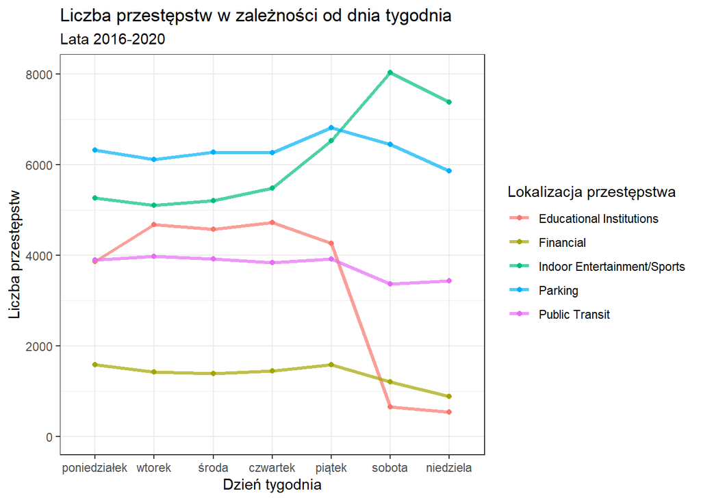

```r
crime_locations_by_weekday %>%
  filter(Location_Category %in% c("Educational Institutions", "Public Transit", "Parking",
                                  "Indoor Entertainment/Sports", "Financial")) %>%
  ggplot(aes(x=Weekday, y=num_crimes, color= Location_Category, group=Location_Category)) +
  geom_point() +
  geom_line(size=1.1, alpha=0.7) +
  expand_limits(y=0) +
  labs(title = "Liczba przestępstw w zależności od dnia tygodnia",
       subtitle = "Lata 2016-2020",
       x = "Dzień tygodnia",
       y = "Liczba przestępstw",
       color = "Lokalizacja przestępstwa") +
  theme_bw()
```

### Przeciętna liczba przestępstw w ciągu roku.

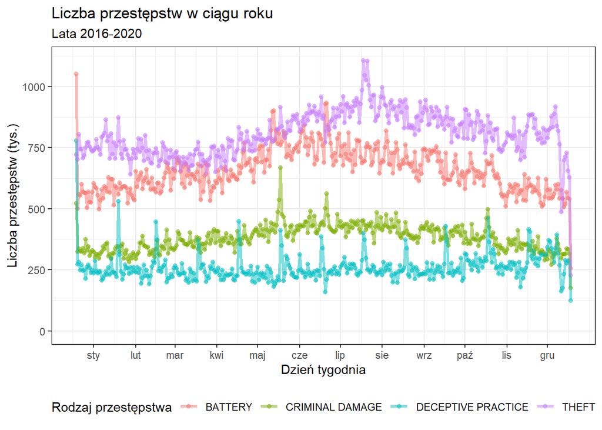

```r
crime_types_by_day <- data %>%
  mutate(year_day = yday(Date)) %>%
  group_by(year_day, Type) %>%
  summarize(num_crimes = n(), .groups = "drop")

crime_types_by_day  %>%
  mutate(year_day = as.Date(year_day, origin = "2020-01-01")) %>% # wykres nie przedstawia roku 2020 tylko sumę ze wszystkich lat
  filter(Type %in% c("THEFT", "BATTERY", "CRIMINAL DAMAGE", "DECEPTIVE PRACTICE")) %>%
ggplot(aes(x=year_day, y=num_crimes, color=Type, group=Type)) +
  geom_point(alpha=0.5) +
  geom_line(size=1.1, alpha=0.5) +
  scale_x_date(breaks = seq(as.Date("2020-01-15"), as.Date("2020-12-30"), by = "1 month"),
    labels = function(x) format(x, "%b") ) +
  scale_y_continuous(breaks = seq(0, 1000, 250)) +
  expand_limits(y=0) +
  labs(title = "Liczba przestępstw w ciągu roku",
       subtitle = "Lata 2016-2020",
       x = "Dzień tygodnia",
       y = "Liczba przestępstw (tys.)",
       color = "Rodzaj przestępstwa") +
  theme_bw() +
  theme(legend.position = "bottom")
```

Widzimy wzrost liczby kradzieży w miesiącach wakacyjnych, z najwyższą liczbą kradzieży odnotowywaną na końcu lipca - początku sierpnia. Wyższe temperatury powodują zapewne, że więcej osób jest na ulicach, co stwarza okazje dla kieszonkowców. Liczba pobić także wzrasta w cieplejszych miesiącach, choć wzrost nie jest tak duży, jak w przypadku kradzieży. Ciekawy jest też wyraźnie widoczny pik w liczbie nieuczciwych praktyk widoczny na początku każdego miesiąca.

### Przestępstwa - jak zmieniały się na przestrzeni lat 2016-2020?

Teraz przejdziemy do analizy liczby przestępstw w czasie.

```r
# przestępstwa pogrupowane na miesiące kolejnych lat
crimes_by_month_year <- data %>%
  mutate(Month = my(paste(month(Date), year(Date), sep="-"))) %>%
  group_by(Month, Type) %>%
  summarize(num_crimes = n(), .groups = "drop")

# przestępstwa pogrupowane wg numeru tygodnia (bez roku)
crimes_by_week <- data %>%
  mutate(Week = week(Date)) %>%
  group_by(Week,  Type) %>%
  summarize(num_crimes = n(), .groups = "drop", )

# przestępstwa pogrupowane wg daty
crimes_by_date <- data %>%
  mutate(Date = date(Date)) %>%
  group_by(Date, Type) %>%
  summarize(num_crimes = n(), .groups = "drop")

# przestępstwa pogrupowane wg numeru tygodnia i roku - domyślnie z datą odpowiadającą poniedziałkowi danego tyg.
crimes_by_week_year <- data %>%
  mutate(
  week = isoweek(Date),
  year = isoyear(Date)
) %>%
  group_by(week, year, Type) %>%
  summarize(num_crimes = n(), .groups = "drop") %>%
  mutate(week_year = as.Date(paste(year, week, 1, sep = "-"), format = "%Y-%W-%u")) %>% arrange(week_year)

# przestępstwa pogrupowane wg daty i godziny
crimes_by_date_hour <- data %>%
  mutate(date_hour = ymd_h(paste(date(Date), hour(Date), sep=", "))) %>%
  group_by(date_hour, Type) %>%
  summarize(num_crimes = n(), .groups = "drop")
```

Spróbujemy zwizualizować szereg czasowy - dla kilku wybranych typów przestępstw policzymy tygodniowe liczby zgłoszeń.

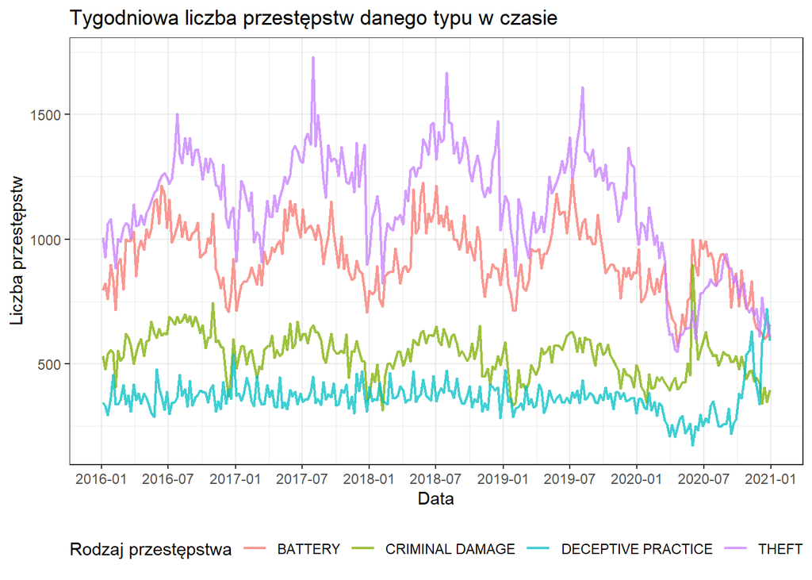

```r
crimes_by_week_year %>%
  filter(Type %in% c("THEFT", "BATTERY", "CRIMINAL DAMAGE", "DECEPTIVE PRACTICE")) %>%
  ggplot(aes(x=week_year, y=num_crimes, color=Type)) +
  geom_line(size=0.75, alpha=0.75) +
  scale_x_date(breaks = as.Date("2016-01-01") %m+% months(seq(0, 60, 6)),
               labels = function(x) format(x, "%Y-%m") ) +
  labs(title = "Tygodniowa liczba przestępstw danego typu w czasie",
       x = "Data",
       y = "Liczba przestępstw",
       color = "Rodzaj przestępstwa") +
  theme_bw() +
  theme(legend.position = "bottom")
```

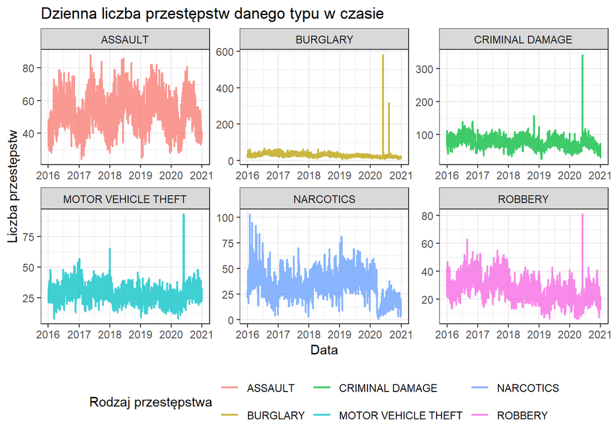

```r
crimes_by_date %>%
  filter(Type %in% c("ROBBERY", "MOTOR VEHICLE THEFT",
                     "ASSAULT", "NARCOTICS", "BURGLARY",
                     "CRIMINAL DAMAGE")) %>%
  ggplot(aes(x=Date, y=num_crimes, color=Type)) +
  geom_line(size=0.75, alpha=0.75) +
  scale_x_date(breaks = seq(as.Date("2016-01-01"), as.Date("2021-01-01"), by="12 months"),
               labels = function(x) format(x, "%Y")) +
  facet_wrap(~Type, scale="free", ncol=3) +
  labs(title = "Dzienna liczba przestępstw danego typu w czasie",
       x = "Data",
       y = "Liczba przestępstw",
       color = "Rodzaj przestępstwa") +
  theme_bw() +
  theme(legend.position = "bottom")
```

W okolicach 1 kwartału 2020 roku widzimy mocny spadek liczby przestępstw związanych z narkotykami. Być może było to spowodowane zamknięciem granic USA w związku z pandemią i trudniejszym nielegalnym importem narkotyków. Dla rabunków (robbery) i włamań (burglary), a także dla zniszczenia mienia (criminal damage) i kradzieży pojazdów widoczny jest ewidentny pik w okolicach końca 1 połowy 2020 roku. Przyjrzyjmy się bliżej temu fragmentowi szeregu czasowego.

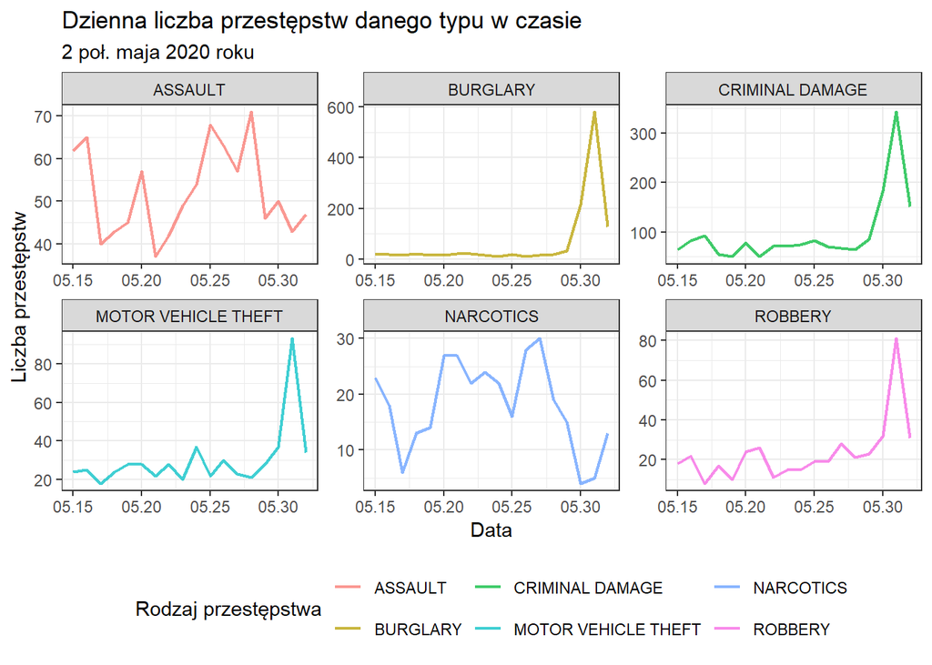

```r
crimes_by_date %>%
  filter(Date >= "2020-05-15", Date <= "2020-06-01") %>%
  filter(Type %in% c("ROBBERY", "MOTOR VEHICLE THEFT", "ASSAULT", "NARCOTICS", "BURGLARY", "CRIMINAL DAMAGE")) %>%
  ggplot(aes(x=Date, y=num_crimes, color=Type)) +
  geom_line(size=0.75, alpha=0.75) +
  scale_x_date(breaks = seq(as.Date("2020-05-15"), as.Date("2020-06-01"), by="5 days"),
               labels = function(x) format(x, "%m.%d")) +
  facet_wrap(~Type, scale="free") +
  labs(title = "Dzienna liczba przestępstw danego typu w czasie",
       subtitle = "2 poł. maja 2020 roku",
       x = "Data",
       y = "Liczba przestępstw",
       color = "Rodzaj przestępstwa") +
  theme_bw() +
  theme(legend.position = "bottom")
```

Pik wystąpił w dniu 31.05.2020. 25 maja świat obiegła informacja o zamordowaniu George Floyda przez amerykańskiego policjanta, w następnych dniach miała miejsce seria protestów. W Chicago największe demonstracje i zamieszki były właśnie 31 maja, miasto odnotowało wtedy 65 tys. telefonów na 911, w porównaniu ze średnią dzienną liczbą 15 tys.

Aby lepiej zobaczyć zmiany liczby przestępstw w czasie, zwizualizujemy dane obejmujące lata 2016-2019 (brak wpływu pandemii i brak obserwacji odstającej z 31 maja).

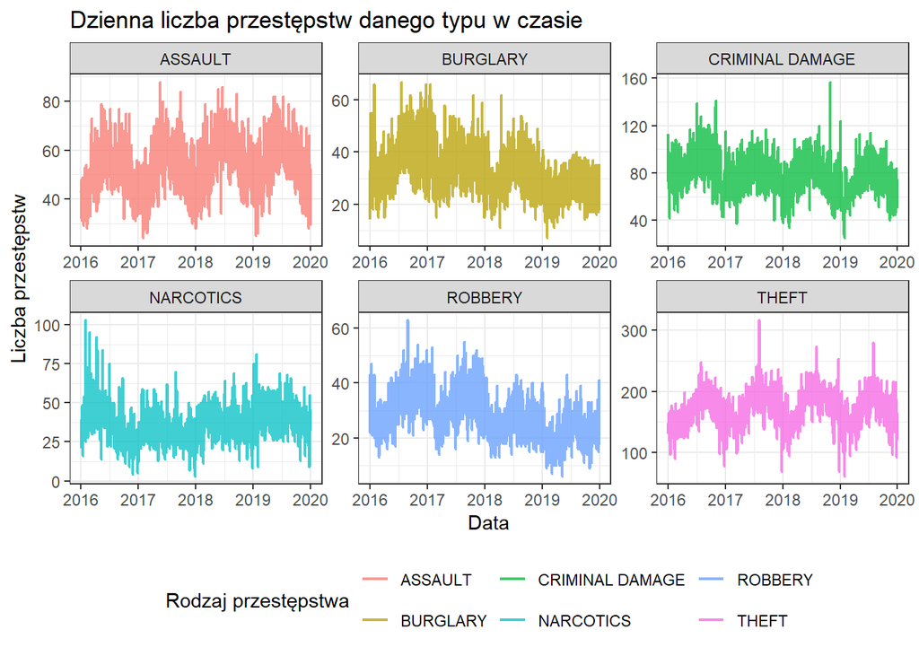

```r
crimes_by_date %>%
  filter(Type %in% c("ROBBERY", "THEFT", "ASSAULT", "NARCOTICS", "BURGLARY", "CRIMINAL DAMAGE")) %>%
  filter(Date <= "2019-12-31") %>%
  ggplot(aes(x=Date, y=num_crimes, color=Type)) +
  geom_line(size=0.75, alpha=0.75) +
  scale_x_date(breaks = seq(as.Date("2016-01-01"), as.Date("2021-01-01"), by="12 months"),
               labels = function(x) format(x, "%Y")) +
  facet_wrap(~Type, scale="free") +
  labs(title = "Dzienna liczba przestępstw danego typu w czasie",
       x = "Data",
       y = "Liczba przestępstw",
       color = "Rodzaj przestępstwa") +
  theme_bw() +
  theme(legend.position = "bottom")
```

Wygląda na to, że dla niektórych typów przestępstw (napaść, włamanie, zniszczenie mienia czy rabunek) występuje sezonowość - więcej zgłoszeń latem.

```r
# dane do modelu
arima_data <- crimes_by_month_year %>%
  group_by(Month) %>%
  summarize(num_crimes = sum(num_crimes))
```

## Część 3. Budowa modelu - ARIMA / SARIMA

Celem tej części projektu będzie zbudowanie modelu ARIMA w celu zaprognozowania miesięcznej łącznej liczby przestępstw popełnionych w Chicago. Model możemy schematycznie zapisać jako:

$ARIMA(p, d, q)$, gdzie $(p, d, q)$, to parametry części niesezonowej - odpowiadające odpowiednio za autokorelację (AR), opóźnienie (I, liczbę różnic wymaganych do uczynienia szeregu stacjonarnym) i średnią ruchomą (MA).

Bardziej matematyczny zapis modelu to: $y_t' = c + \phi_1 y_{t-1}' + \phi_2 y_{t-2}' + \dots + \phi_p y_{t-p}' + \varepsilon_t - \theta_1 \varepsilon_{t-1} - \dots - \theta_q \varepsilon_{t-q}$, gdzie $y_t'$ to wartość szeregu zróżnicowanego $d$ razy, $\phi_1... \phi_p$ to parametry części autoregresyjnej, $\theta_1... \theta_q$ to parametry części średniej ruchomej.

Jeśli w modelu uwzględniamy sezonowość, to wówczas schematyczny zapis jest następujący: $SARIMA(p, d, q)(P, D, Q)_m$, gdzie $(p, d, q)$ to parametry części niesezonowej (jak wyżej), a $(P, D, Q)$ to analogiczne parametry części sezonowej. $m$ odpowiada za długość okresu (dla okresu rocznego i szeregu miesięcznego $m$=12).

### Stacjonarność

Najpierw zajmijmy się kwestią stacjonarności szeregu czasowego. Jednym ze sposobów jej zweryfikowania jest rozszerzony test Dickeya-Fullera. $H_0$: szereg czasowy jest niestacjonarny; $H_1$: szereg czasowy jest stacjonarny.

```r
# funkcja do przeprowadzania rozszerzonego testu Dickey'a - Fullera
test_stationarity_adf <- function(df, colname) {
    test <- adf.test(df[[colname]])
    return (data.frame(statystyka = round(test$statistic,2),
                pvalue = round(test$p.value,2)))

}

test_stationarity_adf(arima_data, "num_crimes")
```

```
##               statystyka pvalue
## Dickey-Fuller      -4.44   0.01
```

Otrzymana p-wartość jest w rzeczywistości mniejsza od 0.01. R wyświetla ją jednak jako 0.01 z uwagi na fakt, że niskie wartości statystyki testowej nie są stablicowane i w związku z tym nie można podać dokładnej p-wartości (informuje o tym ostrzeżenie, które zostało wyciszone).

To, czy szereg czasowy jest stacjonarny, można też zbadać za pomocą testu Kwiatkowskiego-Phillipsa-Schmidta-Shina. W tym teście hipotezy są przeciwne do tych w teście ADF. A zatem: $H_0$: szereg jest stacjonarny; $H_1$: szereg nie jest stacjonarny.

```r
# funkcja do przeprowadzania testu KPSS
test_stationarity_kpss <- function(df, colname) {
    test <- kpss.test(df[[colname]])

    stat <- round(test$statistic, 3)

    return(data.frame(
      statystyka = stat,
      wart_krytyczna = 0.463
    ))
}
test_stationarity_kpss(arima_data, "num_crimes")
```

```
##            statystyka wart_krytyczna
## KPSS Level      0.594          0.463
```

Obliczona wartość statystyki przewyższa wartość krytyczną - zatem przyjmujemy $H_1$ o niestacjonarności. Sytuacja, w której wyniki obu testów nie są zbieżne, nie jest nietypowa. W takiej sytuacji uznajemy szereg za niestacjonarny i obliczamy pierwsze różnice: $y_t - y_{t-1}$ w celu uzyskania stacjonarności.

```r
stationary <- arima_data %>%
  mutate(diff_crimes = c(NA, diff(num_crimes))) %>%
  filter(!is.na(diff_crimes))
```

Ponownie przeprowadzamy test Dickey’a Fullera i test KPSS w celu zweryfikowania, czy po takiej transformacji szereg jest już stacjonarny.

```r
test_stationarity_adf(stationary, "diff_crimes")
```

```
##               statystyka pvalue
## Dickey-Fuller      -5.19   0.01
```

W teście Dickey’a Fullera bez zmian - różnicowanie daje podstawy do przyjęcia $H_1$ o stacjonarności.

```r
test_stationarity_kpss(stationary, "diff_crimes")
```

```
##            statystyka wart_krytyczna
## KPSS Level      0.076          0.463
```

Teraz również w teście KPSS nie ma podstaw do odrzucenia $H_0$ ($H_0$ - szereg jest stacjonarny, odwrotnie niż w teście ADF). Wnioskujemy zatem, że pierwsze różnice pozwoliły wyeliminować niestacjonarność. W związku z tym parametr $d$ w modelu ARIMA będzie równy 1.

### PACF i ACF

Następnym etapem jest sprawdzenie autokorelacji. Posłużą do tego dwa wykresy, wykres autokorelacji (ACF) i wykres autokorelacji częściowej (PACF). Pozwolą one ustalić wstępną postać modelu ARIMA. Oczywiście wykresy sporządzamy już dla stacjonarnego szeregu różnic.

```r
ggtsdisplay((stationary[["diff_crimes"]]),
main = "Monthly Differenced Time Series")
```

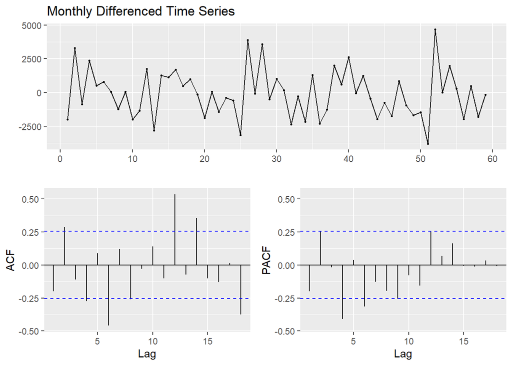

Istotny pik dla opóźnienia 2 w ACF sugeruje parametr q=2 (q odpowiada za komponent średniej ruchomej). Piki dla dla opóźnień 2 i 4 w PACF sugerują parametr p=2 lub p=4 (p odpowiada za komponent autokorelacji). Obliczone zostały pierwsze różnice, dlatego d=1. Wstępnie przetestujemy zatem niesezonowe modele ARIMA z tymi parametrami.

Dodatkowo w ACF istotny jest też pik dla opóźnienia 6, 12 i 18-miesięcznego, co sugeruje sezonowość - spróbujemy z parametrem Q=1 dla okresu (cyklu) 6 i 12 miesięcznego. W PACF występują też piki dla 6 i (na granicy istotności) 12-miesięcznego opóźnienia, które mógłyby odpowiadać parametrowi P=1 dla okresu odpowiednio 6 i 12 miesięcznego.

Przetestujemy wszystkie kombinacje parametrów (dla modelu bez sezonowości i z jej uwzględnieniem - model SARIMA). Modele będą trenowane na szeregu czasowym obejmującym lata 2016-2018. Zbiór testowy będzie obejmował rok 2019 (roku 2020 nie uwzględniamy z uwagi na gwałtowny spadek przestępczości po wybuchu pandemii - jego uwzględnienie wpłynęłoby na testowe AIC i RMSE).

### Estymacja modelu ARIMA / SARIMA

```r
# parametry dla modelu ARIMA(p, d, q) - bez sezonowości
without_seasonality <- expand.grid(p=c(2, 4, 6), d = 1, q=2, P =0,D = 0, Q =0, period=0)

# parametry dla modelu SARIMA(p, d, q)(P, D, Q) - z komponentem sezonowym
with_seasonality <- expand.grid(p=c(2,4), d=1, q=2, P=c(0,1), D=c(0,1), Q=c(0, 1), period=c(6, 12))

# ramka danych z testowanymi kombinacjami parametrów
params <- rbind(with_seasonality, without_seasonality)

# podział na dane treningowe i testowe
train_data <- arima_data[year(arima_data$Month) %in% 2016:2018,][["num_crimes"]]
test_data <- arima_data[year(arima_data$Month) %in% 2019:2020,][["num_crimes"]]

# horyzont predykcji - roczny (czyli predykcja dla roku 2019 - nie 2020 przez wzgląd na pandemię)
h <- 12

results <- do.call(rbind, apply(params, 1, function(param_set){
  p <- param_set["p"]
  q <- param_set["q"]
  d <- param_set["d"]
  P <- param_set["P"]
  Q <- param_set["Q"]
  D <- param_set["D"]
  period = param_set["period"]

  model <- Arima(train_data, order= c(p, d, q), seasonal = list(order= c(P, D, Q), period=period ),  )
  result <- data.frame(p=p, d=d, q=q, P = P, D = D, Q =Q, period = period,
    AIC = model$aic,
    train_RMSE = sqrt(mean((train_data - fitted(model))^2)),
    test_RMSE = sqrt(mean((test_data[1:h] - forecast(model, h)$mean)^2)))
  }
))

results <- results %>% arrange(test_RMSE)
results
```

```
##     p d q P D Q period      AIC train_RMSE test_RMSE
## p19 4 1 2 1 0 0     12 600.7670   856.9569  771.7619
## p29 4 1 2 0 1 1     12 391.8363   546.9431  779.6115
## p31 4 1 2 1 1 1     12 393.8028   482.0455  782.8653
## p23 4 1 2 1 1 0     12 391.8908   568.2175  783.2980
## p28 2 1 2 0 1 1     12 388.0163   559.6516  783.5829
## p30 2 1 2 1 1 1     12 390.0268   575.5303  784.7940
## p22 2 1 2 1 1 0     12 388.0272   575.8215  787.0992
## p14 2 1 2 1 1 1      6 509.4099   726.4842  811.4554
## p18 2 1 2 1 0 0     12 603.1021   848.1626  827.0626
## p6  2 1 2 1 1 0      6 509.1143   819.9472  852.3988
## p7  4 1 2 1 1 0      6 510.8124   749.8611  858.0314
## p20 2 1 2 0 1 0     12 388.3367   649.0087  860.1843
## p21 4 1 2 0 1 0     12 392.0753   645.9713  860.3513
## p25 4 1 2 0 0 1     12 602.3745   890.5156  883.8149
## p26 2 1 2 1 0 1     12 601.1247   696.0208  896.3999
## p27 4 1 2 1 0 1     12 602.7872   667.3253  927.5326
## p11 4 1 2 1 0 1      6 600.0768   747.4937  932.8121
## p10 2 1 2 1 0 1      6 597.2928   715.3007  938.1492
## p34 6 1 2 0 0 0      0 603.4929   882.3091  962.5393
## p15 4 1 2 1 1 1      6 510.2128   665.2340 1043.6077
## p2  2 1 2 1 0 0      6 605.6853   972.4170 1131.6730
## p1  4 1 2 0 0 0      6 602.4706   925.0675 1133.0661
## p17 4 1 2 0 0 0     12 602.4706   925.0675 1133.0661
## p33 4 1 2 0 0 0      0 602.4706   925.0675 1133.0661
## p9  4 1 2 0 0 1      6 604.4550   924.9030 1140.0121
## p3  4 1 2 1 0 0      6 604.4440   924.3276 1144.8369
## p24 2 1 2 0 0 1     12 613.5622  1148.8169 1178.6367
## p8  2 1 2 0 0 1      6 619.3970  1379.4657 1874.4998
## p12 2 1 2 0 1 1      6 530.8957  1380.7874 1895.2314
## p   2 1 2 0 0 0      6 621.9797  1482.1667 1929.7679
## p16 2 1 2 0 0 0     12 621.9797  1482.1667 1929.7679
## p32 2 1 2 0 0 0      0 621.9797  1482.1667 1929.7679
## p13 4 1 2 0 1 1      6 518.5113   810.4493 1956.7976
## p5  4 1 2 0 1 0      6 526.5490  1242.6475 2162.1862
## p4  2 1 2 0 1 0      6 544.1148  1997.4992 4171.9768
```

```r
model <- Arima(train_data, order= c(4, 1, 2), seasonal = list(order= c(0, 1, 1), period=12))
summary(model)
```

```
## Series: train_data
## ARIMA(4,1,2)(0,1,1)[12]
##
## Coefficients:
##           ar1      ar2     ar3      ar4     ma1      ma2     sma1
##       -0.7693  -0.0768  0.0113  -0.0773  0.0006  -0.9994  -0.5749
## s.e.   0.2267   0.2842  0.2938   0.2525  0.5930   0.5929   0.6070
##
## sigma^2 = 673080:  log likelihood = -187.92
## AIC=391.84   AICc=402.12   BIC=400.92
##
## Training set error measures:
##                     ME     RMSE      MAE        MPE    MAPE      MASE
## Training set -42.36852 546.9431 355.6245 -0.2800818 1.62801 0.2606945
##                    ACF1
## Training set 0.09009786
```

Treningowe MAE sugeruje, że na zbiorze treningowym model myli się przeciętnie o około 355 jednostek, czyli o około 1,63% (MAPE). Sprawdzimy jeszcze istotność parametrów modelu.

```r
library(lmtest)
coeftest(model)
```

```
##
## z test of coefficients:
##
##         Estimate  Std. Error z value  Pr(>|z|)
## ar1  -0.76930671  0.22673840 -3.3929 0.0006915 ***
## ar2  -0.07682883  0.28417122 -0.2704 0.7868825
## ar3   0.01129214  0.29379785  0.0384 0.9693408
## ar4  -0.07728006  0.25246258 -0.3061 0.7595247
## ma1   0.00058619  0.59298810  0.0010 0.9992113
## ma2  -0.99939477  0.59291877 -1.6856 0.0918823 .
## sma1 -0.57494366  0.60703706 -0.9471 0.3435720
## ---
## Signif. codes:  0 '***' 0.001 '**' 0.01 '*' 0.05 '.' 0.1 ' ' 1
```

Jak widać, jedynie niesezonowy parametr autoregresyjny okazuje się być istotny statystycznie na poziomie istotności 5%. Zatem na obserwację $y_t$ istotny wpływ ma obserwacja $y_{t-1}$, ale już nie $y_{t-2}$, $y_{t-3}$ czy $y_{t-4}$. Na poziomie istotności 10% moglibyśmy jeszcze wnioskować o wpływie błędu $\varepsilon_{t-2}$ na $y_t$.

Spróbujmy wyestymować model AR(1), zawierający tylko parametr istotny statystycznie, aby porównać go z otrzymanym modelem SARIMA.

```r
model_ar1 <- Arima(train_data, order=c(1, 0, 0))
summary(model_ar1)
```

```
## Series: train_data
## ARIMA(1,0,0) with non-zero mean
##
## Coefficients:
##          ar1        mean
##       0.5994  22334.3559
## s.e.  0.1299    616.8996
##
## sigma^2 = 2510104:  log likelihood = -315.52
## AIC=637.04   AICc=637.79   BIC=641.79
##
## Training set error measures:
##                    ME     RMSE      MAE        MPE     MAPE      MASE
## Training set 35.54722 1539.693 1284.188 -0.3549058 5.915517 0.9413884
##                     ACF1
## Training set -0.03026163
```

Model AR(1) jest gorszy od otrzymanego wcześniej modelu SARIMA - ma wyższe wartości zarówno MAPE i RMSE, jak i kryteriów informacyjnych (AIC, BIC).

Zatem najlepszy model to $SARIMA(4,1,2)(0,1,1)_{12}$, postaci: $y_t' = c + \phi_1 y_{t-1}' + \phi_2 y_{t-2}' + \phi_3 y_{t-3}' + \phi_4 y_{t-4}' + \varepsilon_t - \theta_1 \varepsilon_{t-1} - \theta_2 \varepsilon_{t-2} + \Theta_1 \varepsilon_{t-12}$, gdzie $y_t'$ to wartość szeregu zróżnicowanego $d$ razy, $\phi_1... \phi_p$ to parametry części autoregresyjnej, $\theta_1... \theta_q$ to parametry przy błędach poprzednich predykcji (część niesezonowa), $\Theta_1$ odpowiada za uwzględnienie błędu predykcji sprzed 12 m-cy (część sezonowa).

Sprawdzamy rozkład i autokorelację reszt dla najlepszego modelu.

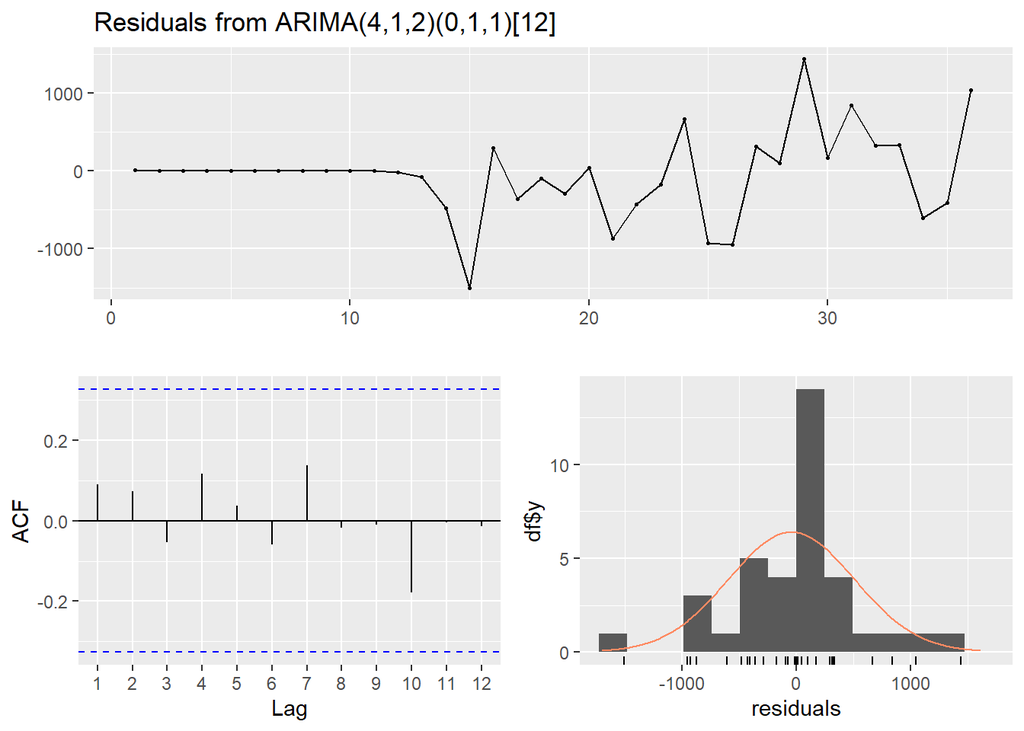

```
##
##  Ljung-Box test
##
## data:  Residuals from ARIMA(4,1,2)(0,1,1)[12]
## Q* = 4.0584, df = 3, p-value = 0.2552
##
## Model df: 7.   Total lags used: 10
```

```r
checkresiduals(model)
```

Wykres ACF pokazuje brak istotnej autokorelacji reszt w finalnym modelu - to pożądana własność. Potwierdza to też wysokie pvalue w teście Ljunga-Boxa (brak podstaw do odrzucenia $H_0$).

Możemy również sprawdzić normalność reszt - wykorzystamy do tego test Shapiro-Wilka, w którym $H_0$: reszty mają rozkład normalny, $H_1$: reszty nie mają rozkładu normalnego.

```r
shapiro.test(model$residuals)
```

```
##
##  Shapiro-Wilk normality test
##
## data:  model$residuals
## W = 0.93297, p-value = 0.03083
```

Na 5% poziomie istotności odrzucamy $H_0$ i wnioskujemy, że reszty nie mają rozkładu normalnego.

Na koniec wizualizacja prognoz - zarówno in-sample, jak i out-of-sample. Na wykresie uwzględniamy rok 2020 - prognozy rozminęły się wtedy z rzeczywistością z uwagi na pandemię i obserwowany spadek przestępczości.

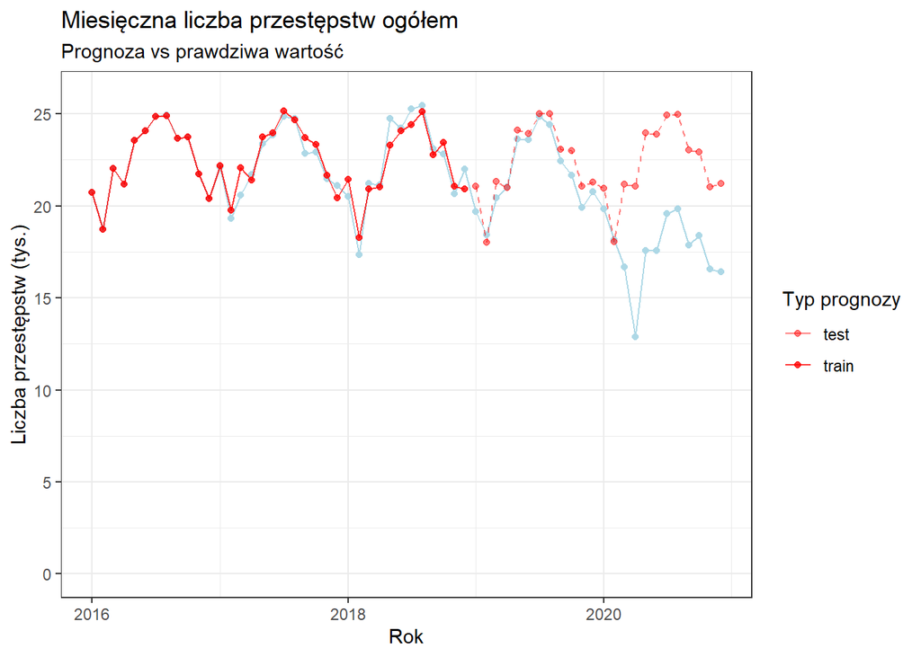

```r
# horyzont prognozy
h <- 24

# prognoza out-of-sample
pred_values <- forecast(model, h=h)$mean

# wektor połączonych prognoz in-sample i out-of-sample
pred = c(fitted(model), pred_values)

train_test_labels =  c(rep("train", times = length(train_data)), rep("test", times = h))

df <- cbind(arima_data, pred, train_test_labels)

ggplot(df, aes(x = Month, y = num_crimes)) +
  geom_point(color = "lightblue") +
  geom_line(color = "lightblue") +
  geom_point(aes(y = pred, alpha = train_test_labels), color = "red") +
  geom_line(aes(y = pred, linetype = train_test_labels, alpha = train_test_labels), color = "red") +
  scale_linetype_manual(values = c("train" = "solid", "test" = "dashed")) +
  scale_alpha_manual(values = c("train" =  0.8, "test" =  0.5)) +
  scale_y_continuous(limits = c(0, 26e3), breaks = seq(0, 25e3, 5e3), labels = function(x) x/1000) +
  theme_bw() +
  labs(
    title = "Miesięczna liczba przestępstw ogółem",
    subtitle = "Prognoza vs prawdziwa wartość",
    x = "Rok",
    y = "Liczba przestępstw (tys.)",
    alpha = "Typ prognozy",
  )  + guides(linetype = "none")
```